# Vector Autoregressive Models (VAR)

Michael Winton

## Unit Root Nonstationarity Tests

When investigating a relationship between two time series variables, we need to check whether the two models are nonstationary (ie. have unit roots). If they are, we need to decide whether or not there is a common stochastic trend. This check for stationarity will be an important step to do before any multivariate time series analysis.

Recall that a characteristic equation of an AR process must have (absolute value of) all roots > 1 in order to be stationarity. If there is a root of 1 – a “unit root” – then that process is nonstationary. This allows for unit root tests for stationarity.

### Augmented Dickey-Fuller Test

The Augmented Dickey-Fuller (ADF) test is a test for a unit root in a time series. The null hypothesis is that there is a unit root (ie. nonstationarity).

The original Dickey-Fuller test was of the null hypothesis that $\phi=1$ vs. an alternate hypothesis that $\phi<1$ in the AR(1) model $x_t = x_{t-1} + u_t$ (where $u_t = w_t$ is white noise). The augmented Dickey-Fuller test expanded to allow $u_t$ to be any stationary process, rather than strictly white noise. The ADF test approximates that stationary process with an AR model. The length of the time series determines the power of the ADF test. In R, we use the `tseries::adf.test` function.

According to the Cowper book, “The null hypothesis of a unit root is favoured by economists because many financial time series are better approximated by random walks than by a stationary process, at least in the short term.”

```r
library(tseries)
```

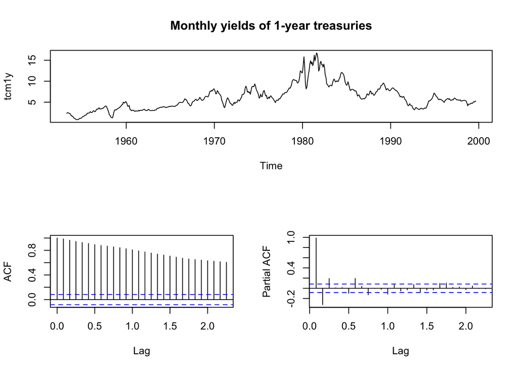

```r
data(tcm)  # built-in data on monthly treasury yields
layout(matrix(c(1,1,2,3), 2, 2, byrow = TRUE))
plot(tcm1y, main='Monthly yields of 1-year treasuries')
acf(tcm1y, main=NA)
pacf(tcm1y, main=NA)
```

```r
adf.test(tcm1y)
```

```
##
##  Augmented Dickey-Fuller Test
##
## data:  tcm1y
## Dickey-Fuller = -2.1, Lag order = 8, p-value = 0.5
## alternative hypothesis: stationary
```

The plot shows this data clearly isn’t stationary. The large p-value from the ADF test tells us we do *not* reject the null hypothesis of unit root (ie. nonstationarity). A very persistent ACF plot, combined with a PACF plot that quickly drops off sharply are also evidence of a process having a unit root (ie. nonstationary).

### Phillips-Perron Test

This procedure estimates the autocorrelations in the stationary process $u_t$ directly, using a kernel smoother, rather than assuming the AR approximation. Because of this, it’s considered a semi-parametric test. This shares the same null hypothesis as the ADF test (that there is a unit root, ie. process is non-stationary). Critical values can be based on asymptotic theory or simulations. In R, we use `tseries::pp.test`.

```r
pp.test(tcm1y)
```

```
##
##  Phillips-Perron Unit Root Test
##
## data:  tcm1y
## Dickey-Fuller Z(alpha) = -11, Truncation lag parameter = 6,
## p-value = 0.5
## alternative hypothesis: stationary
```

Again, we fail to reject the null hypothesis of a unit root (ie. non-stationarity).

### Kwiatkowski-Phillips-Schmidt-Shin (KPSS) test

In contrast to the other tests, the KPSS test has a null hypothesis of stationarity.

```r
kpss.test(tcm1y)
```

```
##
##  KPSS Test for Level Stationarity
##
## data:  tcm1y
## KPSS Level = 3.2, Truncation lag parameter = 5, p-value = 0.01
```

With this test, we reject the null hypothesis of stationarity.

## Multiple Time Series - Context

Classical linear regression models assume that stochastic errors are *uncorrelated*. That assumption is *not* valid for time series data. **Two independent time series may actually *appear* to be correlated to each other, when in reality they are just coincidental, or are both driven by some third factor. This is called “spurious correlation”.**

Don’t fall for temptation to fit a regression from one trending time series on another and report high $R^2$. Common (bad) example: analysts plotting company revenue against macroeconomic time series.

The reason we do unit root tests for nonstationarity is that if two time series are independent and contain unit roots (e.g. they follow independent random walks or at otherwise nonstationary), then we may see an *apparent* linear relationship, due to *chance similarity* of the processes over the period of the time series. That apparent correlation would be spurious.

Is correlation a good measure of the dependency of two time series? No. The sample mean is only a good estimator when you can assume data is iid – not the case for time series data. Because sample variance, covariance, and correlation calculations use the sample mean, we correlation is not a good measure of dependency between the time series. High calculated “correlations” may mean nothing, or even worse, could be misleading.

## Cointegration

We can also see cases wherein two individual time series *do have unit roots*, but are actually related. In other words, they share a common stochastic trend, rather than a spurious correlation. We refer to these as *cointegrated*. The formal definition of cointegration is that: two non-stationary time series $x_t, y_t$ are cointegrated if some linear combination of them ($a x_t + b y_t$) is stationary.

### Random Walk Example

Let’s make up a hypothetical example, with a random walk process $\mu_t$:

$$\mu_t = \mu_{t-1} + w_t$$
Then let’s also assume we have two time series:

$$x_t = \mu_t + w_{x,t}$$

$$y_t = \mu_t + w_{y,t}$$
where $w_{x,t}$ and $x_{y,t}$ are independent white noise series with zero mean. These two time series $x_t$ and $y_t$ are both nonstationary. However, their difference is stationary because it’s a linear combination of (stationary) white noise terms:

$$x_t - y_t = \mu_t + w_{x,t} - \mu_t - w_{y,t} = w_{x,t} - w_{y,t}$$
Hence these two time series are cointegrated because they share the same underlying stochastic trend $\mu_t$.

### Phillips-Ouliaris test for cointegration

The Phillips-Ouliaris (PO) tests the null hypothesis that the two series are *not* cointegrated. This is implemented in R as `tseries::po.test`. The function requires the series be given in matrix form.

Let’s simulate the example given above and test it:

```r
x <- y <- mu <- rep(0, 1000) # initialize to zeros
for (t in 2:1000) {
  mu[t] = mu[t-1] + rnorm(1)
}
x <- mu + rnorm(1000)
y <- mu + rnorm(1000)

# look at a few simulated observations
head(cbind(mu,x,y))
```

```
##          mu       x        y
## [1,] 0.0000  0.2760 -0.06082
## [2,] 0.9795 -0.9847  2.18429
## [3,] 2.3479  1.5978  4.36934
## [4,] 3.6126  2.9148  5.54179
## [5,] 4.6441  5.0587  3.00763
## [6,] 4.9815  5.6658  4.11682
```

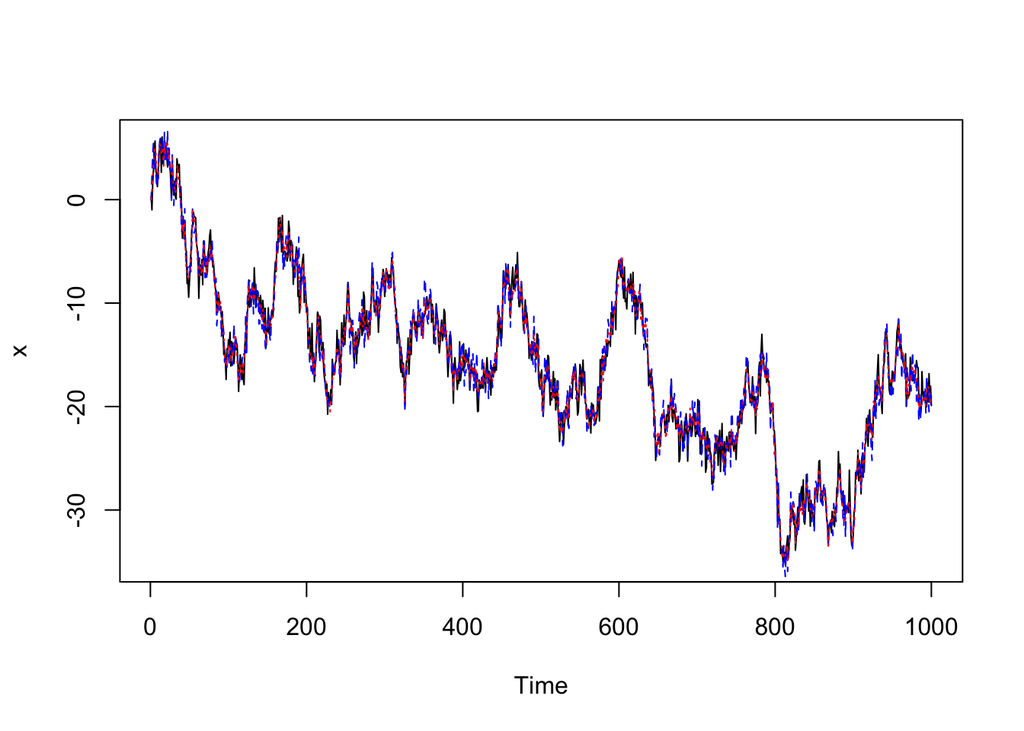

```r
# plot the time series
par(mfrow=c(1,1))
ts.plot(x)
lines(y, col='blue', lty='dashed')
lines(mu, col='red', lty='dotted')
```

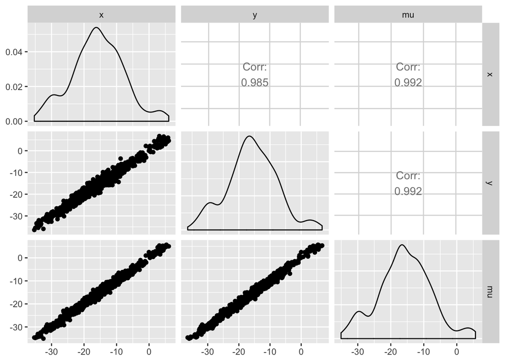

```r
# convert data into dataframe to do scatterplot matrix
tmp <- data.frame(x=x,y=y,mu=mu)
ggpairs(tmp)
```

```r
# perform the ADF test on each:
adf.test(x)$p.value
```

```
## [1] 0.03844
```

```r
adf.test(y)$p.value
```

```
## [1] 0.04053
```

```r
po.test(cbind(x,y))  # need to bind the time series variables into a dataframe
```

```
##
##  Phillips-Ouliaris Cointegration Test
##
## data:  cbind(x, y)
## Phillips-Ouliaris demeaned = -990, Truncation lag parameter = 9,
## p-value = 0.01
```

The statistically significant p-value in the PO test tells us that we can reject the null hypothesis that they are not cointegrated, thus providing evidence for cointegration.

## Vector AR Models

Let’s look at a simple case of a VAR(1) model ($w_{x,t}$ and $w_{y,t}$ are *bivariate* white noise):

$$x_t = \phi_{11} x_{t-1} + \phi_{12} y_{t-1} + w_{x,t}$$
$$y_t = \phi_{21} x_{t-1} + \phi_{22} y_{t-1} + w_{y,t}$$
In vector form, this can be written as:

$$\bf{Z_t = \Phi Z_{t-1} + w_t}$$
where $\bf{Z_t} = {{x_t} \choose{y_t}}$, $\bf{\Phi} = {{\phi_{11}\ \phi_{12}} \choose {\phi_{21}\ \phi_{22}}}$ and $\bf{w_t} = {w_{x,t} \choose w_{y,t}}$.

This can also be expressed in terms of the backshift operator:
$$[I -\Phi(B)] Z_t = w_t$$

Stationarity of a $AR(P)$ model is defined similarly to an $AR(p)$ model: roots of the characteristic equation must all be outside the unit circle. The characteristic equation is the *determinant* of the $\bf{I -\Phi( } B \bf{)}$ matrix. This can be solved algebraically, but in R we use `Mod(polyroot(...))` or `abs(polyroot(...))` (equivalent).

For example, if we have the following parameter matrix:

$$\Phi(B) =\left[ {\begin{array}{cc}
0.4 & 0.3 \\
0.2 & 0.1 \\
\end{array} } \right]$$

The characteristic polynomial is:
$$I - \Phi(B) =\left[ {\begin{array}{cc}
1-0.4x & 0.3x \\
0.2x & 1-0.1x \\
\end{array} } \right]$$
Now, taking the determinant, we get this polynomial:
$$= (1-0.4x)(1-0.1x)-(0.3x)(0.2x) = 1 - 0.4x - 0.1x + 0.04x^2 - 0.06x^2 = 1 -0.5x - 0.02 x^2$$
Plugging in to R to solve for the roots, we get:

```r
# these two are equivalent
Mod(polyroot(c(1,-0.5,-0.02)))
```

```
## [1]  1.861 26.861
```

```r
abs(polyroot(c(1,-0.5,-0.02)))
```

```
## [1]  1.861 26.861
```